# 07: Statistical Analysis

← Prev: Clustering

```r
library(flowWorkspace)
library(tidyverse)
library(ggplot2)
```

```r
gs <- load_gs("data/processed/PBMC_gs_gated")
```

This script extracts the numbers we actually want to report: cell frequencies and marker expression. With a single PBMC sample we can demonstrate the extraction and visualisation code. Statistical comparisons between groups require multiple samples — the code structure for that is shown at the end of this script.

## Cell frequencies

### T cell frequency

Report frequencies as percentage of the parent gate rather than absolute counts. Absolute counts depend on how much sample you started with, which introduces variation unrelated to biology.

```r
stats <- gs_pop_get_stats(gs, nodes = gs_get_pop_paths(gs), type = "percent")
stats
```

```
##    sample                               pop   percent
##    <char>                            <char>     <num>
## 1:   PBMC                              root 1.0000000
## 2:   PBMC                       /leukocytes 0.9363088
## 3:   PBMC              /leukocytes/singlets 0.9994781
## 4:   PBMC         /leukocytes/singlets/live 0.9669278
## 5:   PBMC /leukocytes/singlets/live/T_cells 0.6406841
```

```r
tcell_pct <- stats %>%
  dplyr::filter(pop == "/leukocytes/singlets/live/T_cells") %>%
  pull(percent)

cat("T cells as % of live singlets:", round(tcell_pct * 100, 1), "%\n")
```

```
## T cells as % of live singlets: 64.1 %
```

### CD4 and CD8 frequencies within T cells

```r
tcell_data <- gs_pop_get_data(gs, "T_cells")
expr_tcell <- as.data.frame(exprs(tcell_data[[1]]))

# Gate CD4 and CD8 within T cells using the transformed data
cd4_pct <- mean(expr_tcell$CD4_AF700 > 1.0) * 100
cd8_pct <- mean(expr_tcell$CD8a_BV785 > 1.0) * 100

cat("CD4+ T cells:", round(cd4_pct, 1), "%\n")
```

```
## CD4+ T cells: 43.3 %
```

```r
cat("CD8+ T cells:", round(cd8_pct, 1), "%\n")
```

```
## CD8+ T cells: 58.6 %
```

```r
cat("CD4:CD8 ratio:", round(cd4_pct / cd8_pct, 2), "\n")
```

```
## CD4:CD8 ratio: 0.74
```

A typical healthy adult has a CD4:CD8 ratio of 1.5–2.5. Values outside this range can indicate immune dysregulation.

## Marker expression (MFI)

Median fluorescence intensity (MFI) tells you how much of a marker is expressed on a per-cell basis. Use median rather than mean because flow distributions are often skewed.

```r
marker_channels <- c("CD3_PB", "CD4_AF700", "CD8a_BV785",
                     "CD45RA_PECy7", "CD14_BV605", "CD19_APCCy7")

mfi_vals <- sapply(marker_channels, function(ch) {
  median(expr_tcell[[ch]])
})

data.frame(marker = names(mfi_vals), median_expression = round(mfi_vals, 3))
```

```
##                    marker median_expression
## CD3_PB             CD3_PB             2.742
## CD4_AF700       CD4_AF700             0.098
## CD8a_BV785     CD8a_BV785             3.670
## CD45RA_PECy7 CD45RA_PECy7             0.892
## CD14_BV605     CD14_BV605             0.170
## CD19_APCCy7   CD19_APCCy7            -0.252
```

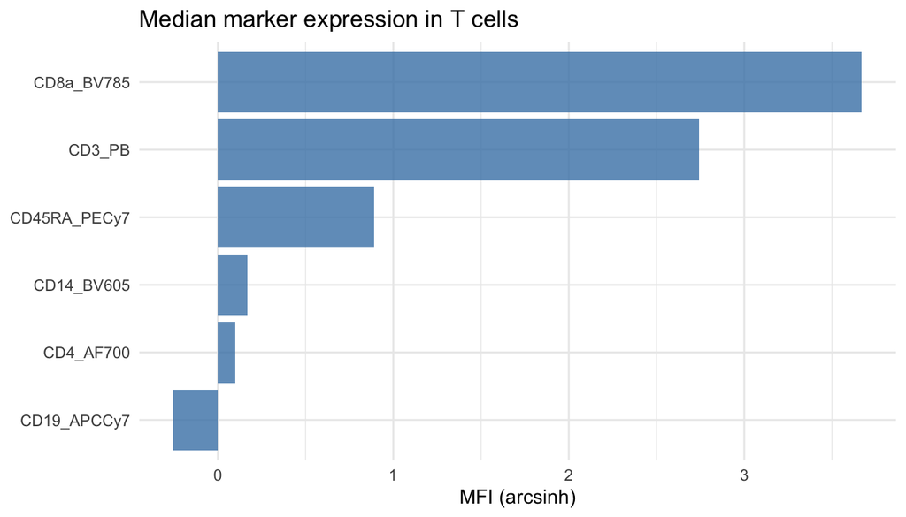

```r
data.frame(marker = names(mfi_vals), MFI = mfi_vals) %>%
  ggplot(aes(x = reorder(marker, MFI), y = MFI)) +
  geom_col(fill = "steelblue", alpha = 0.8) +
  coord_flip() +
  theme_minimal(base_size = 11) +
  labs(title = "Median marker expression in T cells",
       x = NULL, y = "MFI (arcsinh)")
```

## CD45RA: naive vs memory T cells

CD45RA distinguishes naive T cells (high CD45RA, never encountered antigen) from memory T cells (low CD45RA, have been activated). Plotting CD45RA against CD4 or CD8 shows the naive/memory breakdown within each T cell subset.

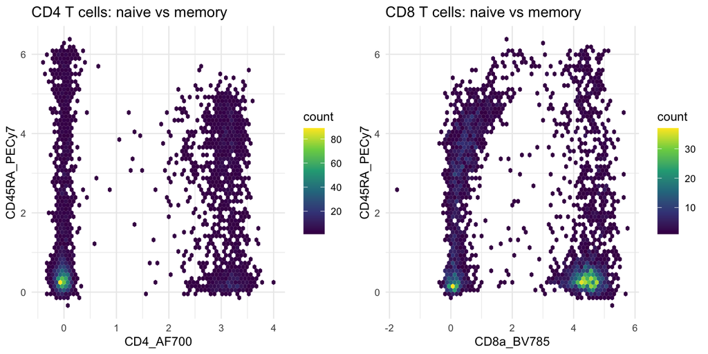

```r
p1 <- ggplot(expr_tcell, aes(x = CD4_AF700, y = CD45RA_PECy7)) +
  geom_hex(bins = 60) +
  scale_fill_viridis_c() +
  theme_minimal(base_size = 10) +
  labs(title = "CD4 T cells: naive vs memory")

p2 <- ggplot(expr_tcell, aes(x = CD8a_BV785, y = CD45RA_PECy7)) +
  geom_hex(bins = 60) +
  scale_fill_viridis_c() +
  theme_minimal(base_size = 10) +
  labs(title = "CD8 T cells: naive vs memory")

gridExtra::grid.arrange(p1, p2, ncol = 2)
```

## Statistical comparisons with multiple samples

The analyses above work on a single sample. For a real experiment comparing groups (e.g., healthy vs. disease, pre- vs. post-treatment), you would apply the same extraction code across all samples and then model the resulting data frame.

The data structure you would build:

```r
# Extract frequencies for all samples
freq_df <- gs_pop_get_stats(gs_multi,
                             nodes = "/leukocytes/singlets/live/T_cells",
                             type  = "percent") %>%
  rename(tcell_pct = percent) %>%
  left_join(pData(gs_multi) %>% rownames_to_column("sample"), by = "sample")
```

For a longitudinal experiment with repeated measures per patient, a linear mixed model accounts for the within-patient correlation:

```r
library(lme4)
library(emmeans)

model <- lmer(tcell_pct ~ treatment + timepoint_days + (1 | patient_id),
              data = freq_df)
summary(model)
emmeans(model, pairwise ~ treatment)
```

For mouse experiments, replace `(1 | patient_id)` with `(1 | cage)`. Always include cage as a random effect in mouse studies — animals in the same cage share environment, microbiome, and social conditions, and this almost always confounds group comparisons.

```r
dir.create("output/tables", recursive = TRUE, showWarnings = FALSE)

write_csv(
  data.frame(
    sample = "PBMC",
    tcell_pct = tcell_pct,
    cd4_pct = cd4_pct,
    cd8_pct = cd8_pct,
    cd4_cd8_ratio = cd4_pct / cd8_pct
  ),
  "output/tables/PBMC_frequencies.csv"
)
```

← Prev: Clustering